# Principal Component Analysis of FDA DGE data

Artem Sokolov

## Preliminaries

Load all the necessary libraries. If any are missing, you can install them using `install.packages` function (e.g., `install.packages("tidyverse")` ). We will also make use of the R Synapse client, which has a separate set of [installation instructions](https://sagebionetworks.jira.com/wiki/display/SYNR/How+to+install+the+Synapse+R+Client).

```r
library( tidyverse )
library( stringr )
library( magrittr )
library( broom )
library( GGally )
library( synapseClient )
```

## Loading and tidying the data

The data for this workflow is [hosted on Synapse](https://www.synapse.org/#!Synapse:syn9952381). We can fetch it programmatically by first logging into Synapse, and then downloading the relevant files using their synapse IDs. By using `rememberMe=TRUE`, we allow the Synapse client to store our credentials locally, preventing the need to retype our username and password every time.

```r
synapseLogin( rememberMe=TRUE )
```

```
Welcome ArtemSokolov!
```

```r
fnX <- synGet( "syn9952383" )@filePath          ## M3.unq.refseq.umi.dat
fnY <- synGet( "syn9952382" )@filePath          ## FDA_DGE_metadata.csv
```

Note that, by default, `synGet` will download files to a local cache directory. We can change this behavior by passing a different value to the `downloadLocation` argument (e.g., `synGet( "syn9952383", downloadLocation = "/data/fda-dge"`).

We will follow tidy data conventions, [as introduced by Hadley Wickham](https://cran.r-project.org/web/packages/tidyr/vignettes/tidy-data.html). Specifically, we need to arrange our data into a format that places each sample into a row with columns corresponding to individual properties, such as expression of a particular gene, or the drug that the sample was treated with.

We begin by loading expression data. Note that by default count tables arrange samples in columns and genes in rows. Thus, our processing steps will consist of a) loading the raw data; b) applying a log2 transform; c) transposing the matrix to place samples into rows; and d) fixing sample names. The last step is necessary because sample names between expression and metadata files are mismatched, and we will need them to match exactly when we merge the two data frames later.

```r
X <- read.delim( fnX, row.names=1 ) %>%                 ## Load the raw data
    add(1) %>% log2() %>%                               ## Apply log transform: log2( x + 1 )
    t() %>% as.data.frame() %>%                         ## Transpose to samples-in-row format
    rownames_to_column( "SampleID" ) %>%                ## Place sample names into their own column
    mutate( SampleID = str_split( SampleID, "_",        ## Fix the names: e.g., T384s1_A1 -> A1
                                 simplify=TRUE )[,2] )
```

Let’s take a look at the first few rows and columns of the data frame, to verify that things look correctly.

```r
X[1:3,1:5]
```

| SampleID | A1BG | A1BG-AS1 | A1CF | A2M |
| --- | --- | --- | --- | --- |
| A1 | 0.000000 | 0 | 0 | 0.000000 |
| A2 | 1.584963 | 0 | 0 | 1.584963 |
| A3 | 1.000000 | 0 | 0 | 1.584963 |

Next, we load the metadata. It is already in the format that contains samples in rows. However, we still need to compose sample IDs to match what is in the expression data frame `X`. We would also like to simplify the column names to avoid overly verbose code. (Note that the original column names can always be saved to another variable and used as visual elements in subsequent plotting.) Finally, because the metadata was stitched from multiple sources, the `Drug` column contains multiple entries for the same compounds in mismatched capitalization. For example, it contains “dmso” and “DMSO”, “Sorafenib” and “sorafenib”. We consolidate the discrepancies by making each drug name capitalized, except DMSO, which is treated as a special case.

```r
Y <- read_csv( fnY ) %>%                                ## Load the raw data
    mutate( SampleID = str_c( Row, Column ) ) %>%       ## Compose the sample IDs from Row, Column
    select( SampleID, Origin = `Sample Origonator`,     ## Select the variables of interest and
           Drug = `Drug treatment or Condition`,        ##   rename them to shorter tags
           Time = `Time of Treatment (Days)`,
           Concentration = `Drug Concentration (uM)` ) %>%
    mutate( Drug = str_to_title(Drug) ) %>%             ## Consolidate capitalization of drug names
    mutate( Drug = ifelse( Drug == "Dmso", "DMSO", Drug ) )
```

Once again, we verify the first few rows and columns of the metadata frame to make sure things look as expected.

```r
Y[1:3,]
```

| SampleID | Origin | Drug | Time | Concentration |
| --- | --- | --- | --- | --- |
| A1 | Mirra | Afatinib | 1 | 1 |
| A2 | Mirra | Afatinib | 5 | 3.16 |
| A3 | Mirra | Afatinib | 1 | 3.16 |

Now that we have both expression and metadata in a tidy format, we can combine everything into a single data frame, using the now-matching sample IDs.

```r
XY <- inner_join( Y, X )
```

Note that by passing `Y` as the first argument, the join operation will place its columns to the left of `X`.

```r
XY[1:3,1:8]
```

| SampleID | Origin | Drug | Time | Concentration | A1BG | A1BG-AS1 | A1CF |
| --- | --- | --- | --- | --- | --- | --- | --- |
| A1 | Mirra | Afatinib | 1 | 1 | 0.000000 | 0 | 0 |
| A2 | Mirra | Afatinib | 5 | 3.16 | 1.584963 | 0 | 0 |
| A3 | Mirra | Afatinib | 1 | 3.16 | 1.000000 | 0 | 0 |

## Principal Components Analysis

We would like to perform PCA on all the “gene” columns in our joint data frame. To say it another way, we would like to exclude columns `SampleID` through `Concentration`, which is accomplished through a simple `select` call. After performing PCA, we augment the original data matrix with the sample projections onto each principal component. The final results matrix is then composed by selecting columns `SampleID` through `Concentration`, and projections onto the first two principal components

```r
PCA <- select( XY, -(SampleID:Concentration) ) %>% prcomp()
RR <- augment( PCA, XY ) %>% select( SampleID:Concentration, .fittedPC1, .fittedPC2 )
RR[1:3,]
```

| SampleID | Origin | Drug | Time | Concentration | .fittedPC1 | .fittedPC2 |
| --- | --- | --- | --- | --- | --- | --- |
| A1 | Mirra | Afatinib | 1 | 1 | -30.50101 | -0.05008641 |
| A2 | Mirra | Afatinib | 5 | 3.16 | 82.32823 | 3.62423011 |
| A3 | Mirra | Afatinib | 1 | 3.16 | 48.21466 | -0.37240636 |

## Plotting the results

It is often useful to present the amount of variance captured by each principal component. This can be retrieved from the `PCA` object computed above. We scale the variance to be percent of the total and wrap it inside some text to be displayed as the axis labels. Because we’re going to be rerunning PCA multiple times, the underlying % variance explained will change, and the labels will need to be re-generated. We wrap the following code inside a function to make our lives easier.

```r
mylabels <- function( i, j )
    {
        pcvar <- PCA$sdev / sum( PCA$sdev ) * 100
        xlabel <- str_c( "PC", i, ": ", round( pcvar[i], 2 ), "% Variance" )
        ylabel <- str_c( "PC", j, ": ", round( pcvar[j], 2 ), "% Variance" )
        labs( x = xlabel, y = ylabel )
    }
```

We are now ready to produce the PCA plot. The plot below is colored by the `Origin` attribute to investigate the presence of potential batch effects.

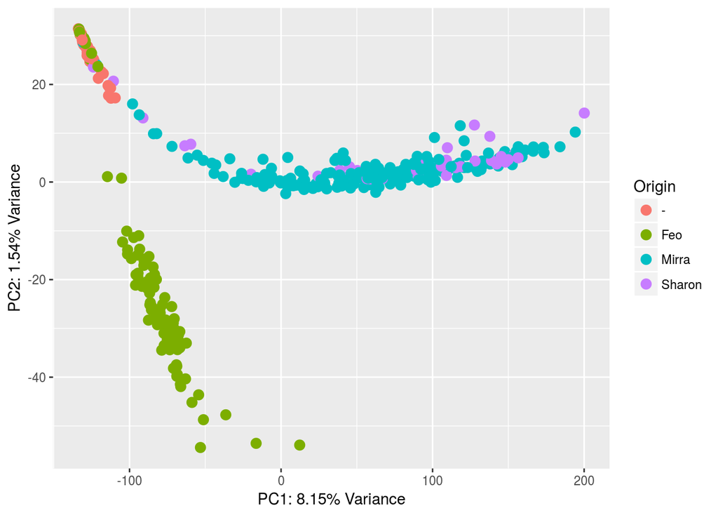

```r
ggplot( RR, aes( x = .fittedPC1, y = .fittedPC2, color = Origin ) ) +
    geom_point( size = 3 ) + mylabels(1,2)
```

The plot above shows a strong batch effect between `Feo` samples and the rest of the data. Let’s repeat the analysis after removing `Feo` and `-` samples (the latter corresponding to empty wells).

## Repeating the analysis on a subset of the data

We begin by filtering the joint matrix according to the `Origin` attribute. We then repeat the PCA workflow, but keep the first few principal components this time

```r
XY <- filter( XY, Origin %in% c( "Sharon", "Mirra" ) )
PCA <- select( XY, -(SampleID:Concentration) ) %>% prcomp()
RR <- augment( PCA, XY ) %>% select( SampleID:Concentration, .fittedPC1:.fittedPC5 )
```

First, we double check that there’s no batch effect in the remaining data

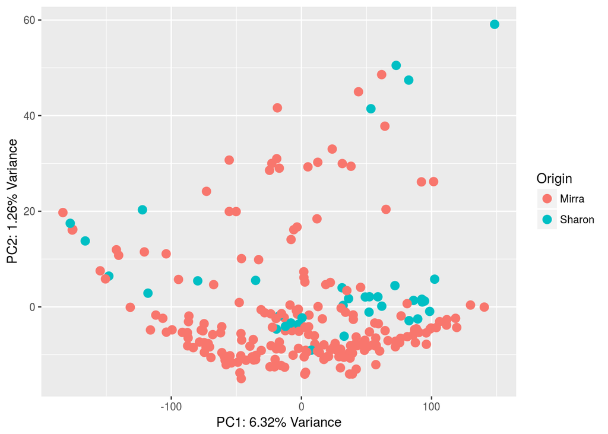

```r
ggplot( RR, aes( x = .fittedPC1, y = .fittedPC2, color = Origin ) ) +
    geom_point( size = 3 ) + mylabels(1,2)
```

We can now recolor the plot by the attributes of interest

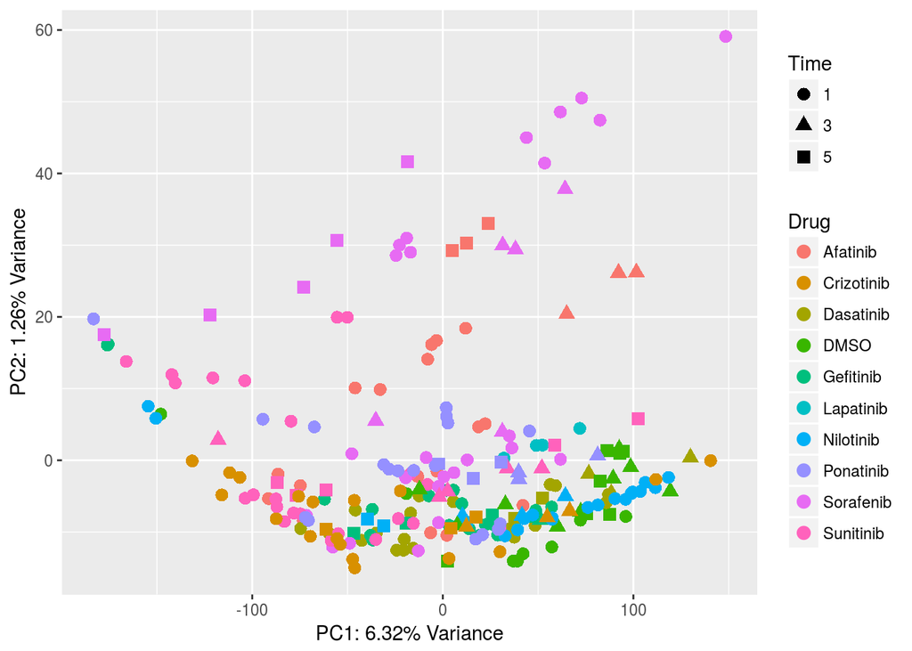

```r
ggplot( RR, aes( x = .fittedPC1, y = .fittedPC2, color = Drug, shape = Time ) ) +
    geom_point( size = 3 ) + mylabels(1,2)
```

or look at other principal components.

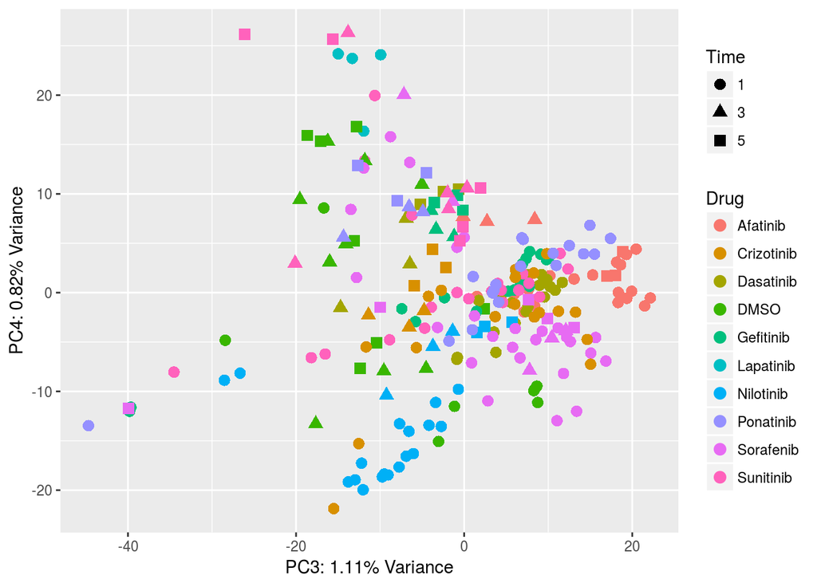

```r
ggplot( RR, aes( x = .fittedPC3, y = .fittedPC4, color = Drug, shape = Time ) ) +
    geom_point( size = 3 ) + mylabels(3,4)
```

Using `ggpairs` function from the `GGally` package, we can also look at multiple principal components at the same time.

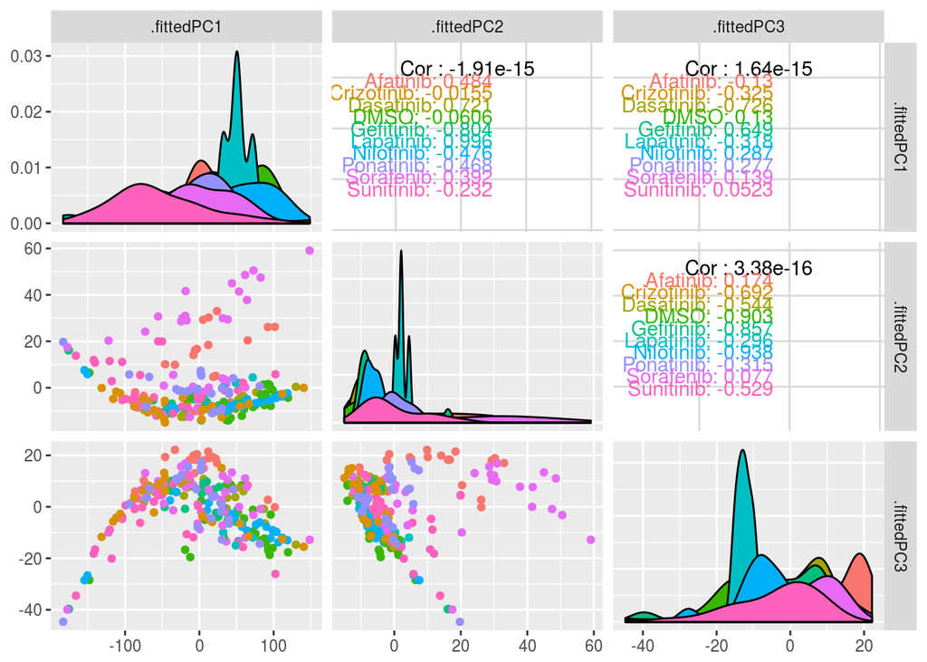

```r
ggpairs( RR, aes( color = Drug ), columns = c( ".fittedPC1", ".fittedPC2", ".fittedPC3" ) )
```